# Data Exploration

BHARATH SHIVADAS KOTIAN

2025-03-31

```r
library(readr)
library(dplyr)
```

```r
library(ggplot2)
library(showtext)
# Load datasets
theme_df <- read_csv("ESS Theme - Personal and social wellbeing.csv")
full_df <- read_csv("ESS6e02_6.csv")
# Drop columns with >50% missing values
theme_cleaned <- theme_df %>% select(where(~ mean(is.na(.)) <= 0.5))
full_cleaned <- full_df %>% select(where(~ mean(is.na(.)) <= 0.5))
```

This code removes all the columns from the data that have too many empty or missing values. It keeps only the columns that have at least half of their data filled in.

```r
# Country code → full name mapping
country_names <- c(
  AL = "Albania", AT = "Austria", BE = "Belgium", BG = "Bulgaria", CH = "Switzerland", CY = "Cyprus",
  CZ = "Czech Republic", DE = "Germany", DK = "Denmark", EE = "Estonia", ES = "Spain",
  FI = "Finland", FR = "France", GB = "United Kingdom", GR = "Greece", HR = "Croatia",
  HU = "Hungary", IE = "Ireland", IL = "Israel", IS = "Iceland", IT = "Italy",
  LT = "Lithuania", LU = "Luxembourg", LV = "Latvia", NL = "Netherlands", NO = "Norway",
  PL = "Poland", PT = "Portugal", RO = "Romania", RU = "Russia", SE = "Sweden",
  SI = "Slovenia", SK = "Slovakia", TR = "Turkey", UA = "Ukraine", XK = "Kosovo"
)

# Step 4: Map full country names
full_cleaned <- full_cleaned %>%
  mutate(country = recode(cntry, !!!country_names))
```

This code changes the short country codes (like “DE” or “FR”) into full country names (like “Germany” or “France”) so that the data is easier to read and understand. It adds a new column called country to the dataset with these full names.

```r
# Clean data uniformly
cleaned_df <- full_df %>%
  filter(
    !is.na(stflife), stflife >= 0, stflife <= 10,
    !is.na(happy), happy >= 0, happy <= 10,
    !is.na(cntry)
  ) %>%
  mutate(
    country = recode(cntry, !!!country_names),
    gender = case_when(gndr == 1 ~ "Male", gndr == 2 ~ "Female", TRUE ~ NA_character_)
  )
```

This code keeps only the rows where the life satisfaction and happiness scores are available and fall between 0 and 10, and the country information is not missing. Then, it adds two new columns: one with full country names and another that changes the gender code into words like “Male” and “Female” to make the data easier to understand.

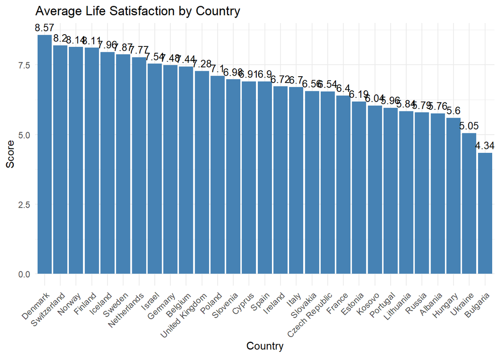

```r
# Average Life Satisfaction by Country
life_sat_country <- cleaned_df %>%
  group_by(country) %>%
  summarise(mean_life_satisfaction = mean(stflife)) %>%
  arrange(desc(mean_life_satisfaction))

ggplot(life_sat_country, aes(x = reorder(country, -mean_life_satisfaction), y = mean_life_satisfaction)) +
  geom_col(fill = "#4682B4") +
  geom_text(aes(label = round(mean_life_satisfaction, 2)), vjust = -0.5, size = 3.5) +
  labs(title = "Average Life Satisfaction by Country", x = "Country", y = "Score") +
  theme_minimal() +
  theme(axis.text.x = element_text(angle = 45, hjust = 1))
```

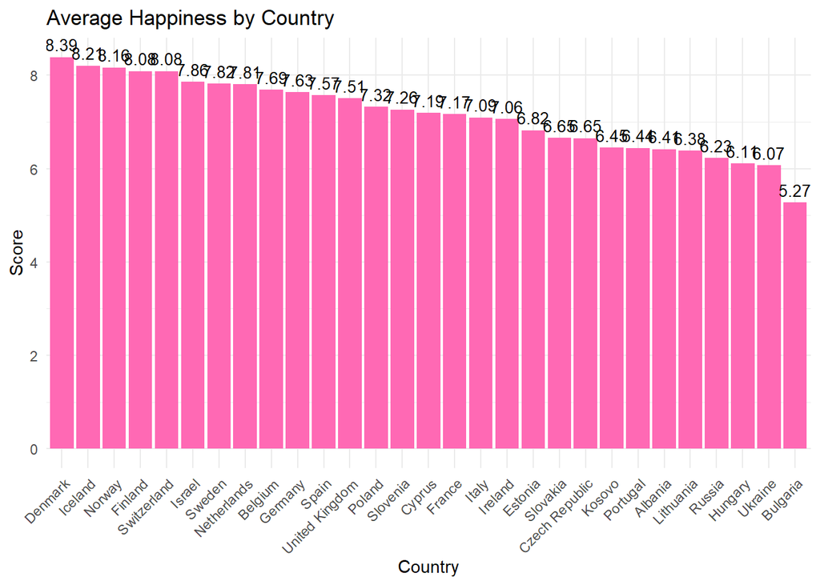

```r
# Average Happiness by Country
happiness_country <- cleaned_df %>%
  group_by(country) %>%
  summarise(mean_happiness = mean(happy)) %>%
  arrange(desc(mean_happiness))

ggplot(happiness_country, aes(x = reorder(country, -mean_happiness), y = mean_happiness)) +
  geom_col(fill = "#FF69B4") +
  geom_text(aes(label = round(mean_happiness, 2)), vjust = -0.5, size = 3.5) +
  labs(title = "Average Happiness by Country", x = "Country", y = "Score") +
  theme_minimal() +
  theme(axis.text.x = element_text(angle = 45, hjust = 1))
```

```r
# Life Satisfaction by Gender and Country
life_by_gender_country <- cleaned_df %>%
  filter(!is.na(gender)) %>%
  group_by(country, gender) %>%
  summarise(mean_life_satisfaction = mean(stflife)) %>%
  ungroup()
```

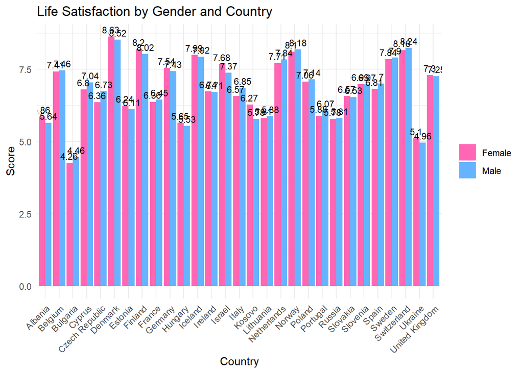

```r
ggplot(life_by_gender_country, aes(x = country, y = mean_life_satisfaction, fill = gender)) +
  geom_col(position = "dodge") +
  geom_text(aes(label = round(mean_life_satisfaction, 2)),
            position = position_dodge(width = 1), vjust = -0.5, size = 3) +
  labs(title = "Life Satisfaction by Gender and Country", x = "Country", y = "Score") +
  scale_fill_manual(values = c("Male" = "#66b3ff", "Female" = "#ff66b3")) +
  theme_minimal() +
  theme(axis.text.x = element_text(angle = 45, hjust = 1),
        legend.title = element_blank())
```

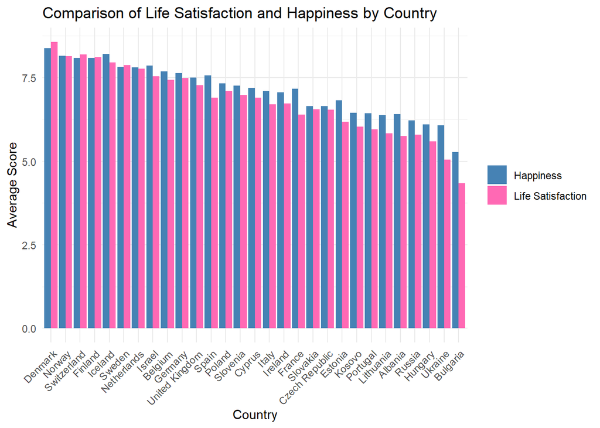

```r
library(dplyr)
library(ggplot2)
library(tidyr)
comparison_df <- cleaned_df %>%
  group_by(country) %>%
  summarise(
    mean_life_satisfaction = mean(stflife),
    mean_happiness = mean(happy)
  ) %>%
  pivot_longer(cols = c(mean_life_satisfaction, mean_happiness),
               names_to = "measure", values_to = "score")


ggplot(comparison_df, aes(x = reorder(country, -score), y = score, fill = measure)) +
  geom_col(position = "dodge") +
  labs(title = "Comparison of Life Satisfaction and Happiness by Country",
       x = "Country", y = "Average Score") +
  scale_fill_manual(
    values = c("mean_life_satisfaction" = "#FF69B4",   # Pink
               "mean_happiness" = "#4682B4"),          # Blue
    labels = c("Happiness", "Life Satisfaction")
  ) +
  theme_minimal() +
  theme(axis.text.x = element_text(angle = 45, hjust = 1),
        legend.title = element_blank())
```

```r
library(dplyr)

# Create a table with average scores for each country
gap_df <- cleaned_df %>%
  group_by(country) %>%
  summarise(
    mean_life_satisfaction = mean(stflife, na.rm = TRUE),
    mean_happiness = mean(happy, na.rm = TRUE)
  ) %>%
  mutate(gap = abs(mean_life_satisfaction - mean_happiness)) %>%  # Absolute difference
  arrange(desc(gap)) %>%
  slice(1:5)  # Take top 5

# View result
print(gap_df)
```

```
## # A tibble: 5 × 4
##   country  mean_life_satisfaction mean_happiness   gap
##   <chr>                     <dbl>          <dbl> <dbl>
## 1 Ukraine                    5.05           6.07 1.02
## 2 Bulgaria                   4.34           5.27 0.931
## 3 France                     6.40           7.17 0.765
## 4 Spain                      6.90           7.57 0.672
## 5 Albania                    5.76           6.41 0.657
```

This output shows the top 5 countries where the gap between life satisfaction and happiness is the largest. For example, in Ukraine, the average life satisfaction is 5.05, while happiness is higher at 6.07 — resulting in a gap of 1.02. These gaps highlight where people’s happiness doesn’t match how satisfied they feel about their overall life.